# Central Limit Theorem comparison for exponential distribution

yogarjun77

Thursday, May 21, 2015

**Preparation:**  
a. Load libraries and determine parameters to be used

```r
library(ggplot2)


lambda = 0.2
n = 40
sim = 1000 #total simulations
set.seed(333)
```

2. Simulation of sample distribution

```r
set.seed(333)
exp2 = NULL
for (i in 1 :sim){
exp2 = c(exp2, mean(rexp(n,lambda)))
}

head(exp2)
```

```
## [1] 5.149061 5.070188 5.632247 5.620609 3.485445 6.225564
```

```r
length(exp2)
```

```
## [1] 1000
```

**1 - Sample mean vs Theoretical Mean**  
Mean of sample set of 1000 averages of 40 exponentials

```r
        mean_exp2 <- round(mean(exp2),3)
        print(mean_exp2)
```

```
## [1] 5.045
```

Theoretical mean(population mean)

```r
        mean_pop <- round(1/lambda, 3)
        print(mean_pop)
```

```
## [1] 5
```

The sample mean (5.045) is almost equal to the theoretical value(5.000), fulfilling the first condition for Central Limit Theorem E[X] = µ.

**2 - Sample Variance vs Theoretical Variance**

Variance of sample set of 1000 averages of 40 exponentials:

```r
        var_exp2 <- round(var(exp2),3)
        print(var_exp2)
```

```
## [1] 0.636
```

```r
        var_exp2 <- (round((((1/lambda)^2)/n),3))
        print(var_exp2)
```

```
## [1] 0.625
```

Again, the sample variance is almost equal to the theoretical value, fulfilling the second condition for CLT:  
Var[X] = sigma<sup>2</sup>/n

**3 - Proving that the distribution is approximately normal**

a)Comparing with a distribution of 1000 exponentials - would it be similar to a normal distribution?

Create a sample distribution of 1000 exponentials

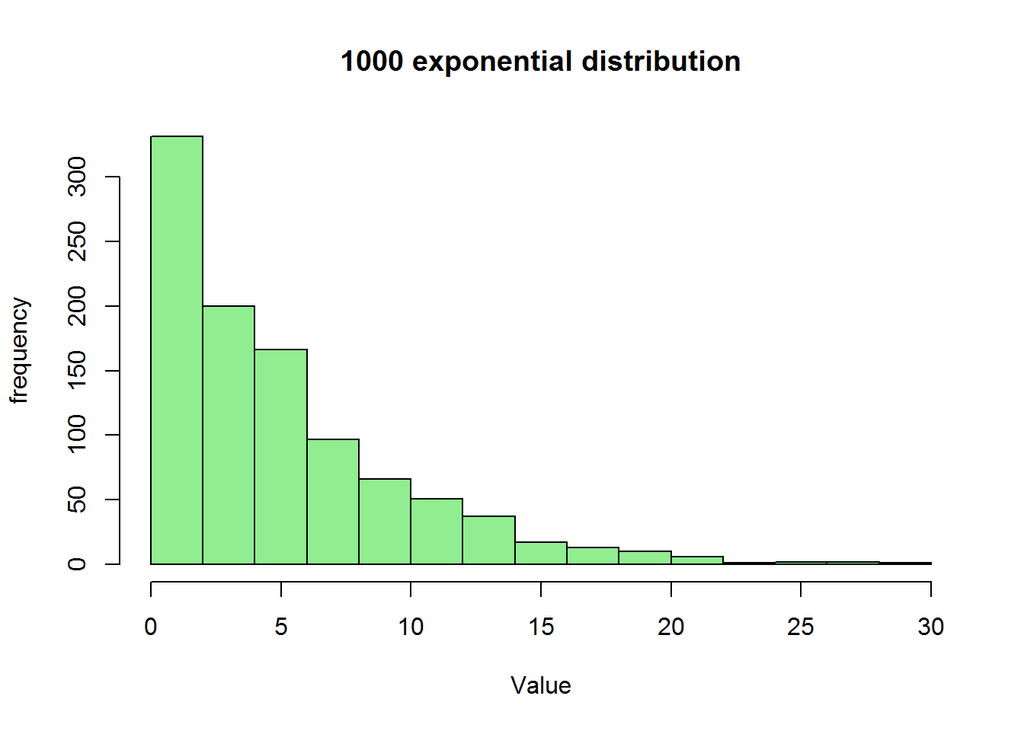

```r
set.seed(333)
exp_th <- rexp(1000, 0.2)
hist(exp_th, col = "lightgreen", xlab = "Value", ylab = "frequency", main = "1000 exponential distribution")
```

Histogram for 1000 averages of 40 exponentials

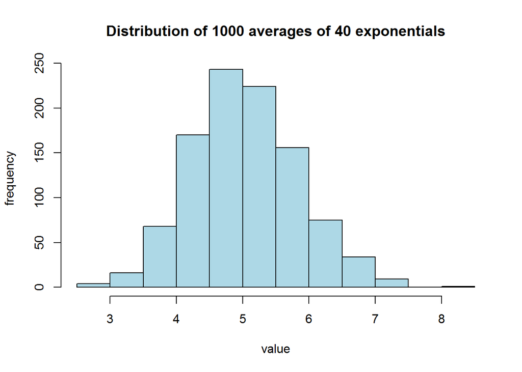

```r
hist(exp2, col = "lightblue", xlab = "value", ylab = "frequency", main = "Distribution of 1000 averages of 40 exponentials")
```

Mean & Variance of 1000 exponential

```r
round(mean(exp_th),3)
```

```
## [1] 4.971
```

```r
round(var(exp_th)/1000, 3)
```

```
## [1] 0.022
```

The histogram and variance values show that a distribution of 1000 exponentials are not similar to a normal distribution.

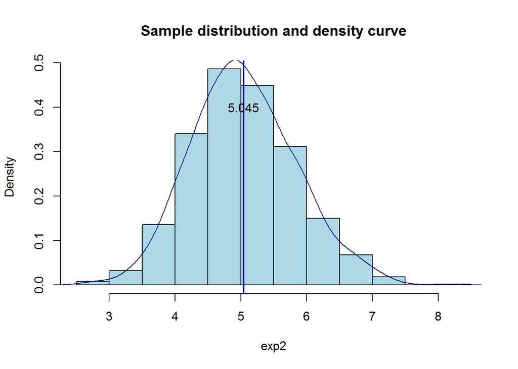

```r
hist(exp2, col= "lightblue", breaks = "sturges", freq = FALSE, main = "Sample distribution and density curve")
abline (v=mean_exp2, col = "darkblue", lwd = 2)
text(mean_exp2,0.4, mean_exp2)
lines(density(exp2), col="darkblue")
```

The distribution exhibits a Gaussian shape almost similar to a normal distribution.

3. Normal Q-Q plot

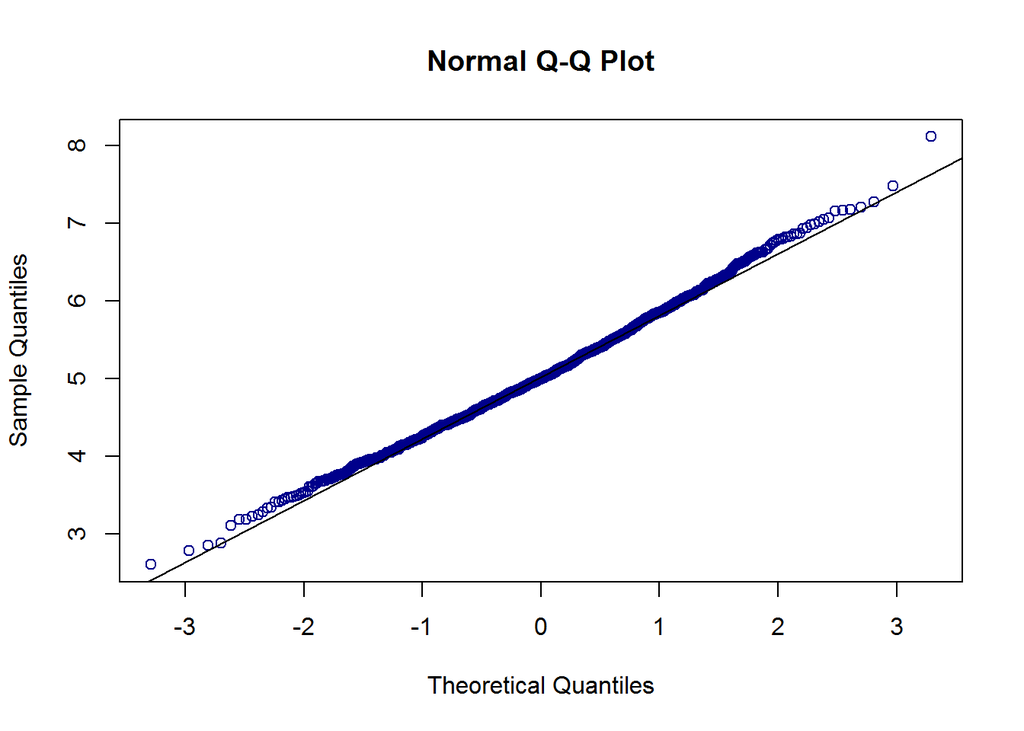

```r
qqnorm(exp2, col = "darkblue")
qqline(exp2, col = "black")
```

A Q-Q (quantile-quantile) plot is more effective to test if a sample is normally distributed. The resulting plots show that the normalized exp_2 (circles) closely fit the theoretical default normal (line).

**Conclusion**  
The sample fulfilled 2 key conditions for the Central Limit Theorem Criteria

1. E[X]=µ
2. Var[X]=sigma<sup>2</sup>/n

The histogram for 1000 averages of 40 exponentials(the sample) and its Q-Q plot positively indicate that the sample exhibits characteristics of a normal distribution according to the Central Limit Theorem.

Additionally just taking 1000 exponentials with the same random seed do not yield a similar distribution.

All these points show proof that the sample is highly similar to a normal distribution based on the Central Limit Theorem.